# Project 5: NLP on Financial Statements

## Preprocess the Data

### Clean Up

As you can see, the text for the documents are very messy. To clean this up, we'll remove the html and lowercase all the text.

```python
def remove_html_tags(text):
    text = BeautifulSoup(text, 'html.parser').get_text()

    return text


def clean_text(text):
    text = text.lower()
    text = remove_html_tags(text)

    return text
```

Using the `clean_text` function, we'll clean up all the documents.

```python
for ticker, ten_ks in ten_ks_by_ticker.items():
    for ten_k in tqdm(ten_ks, desc='Cleaning {} 10-Ks'.format(ticker), unit='10-K'):
        ten_k['file_clean'] = clean_text(ten_k['file'])


project_helper.print_ten_k_data(ten_ks_by_ticker[example_ticker][:5], ['file_clean'])
```

```
[
  {
    file_clean: '\n10-k\n1\namzn-20161231x10k.htm\nform 10-k\n\n\n...},
  {
    file_clean: '\n10-k\n1\namzn-20151231x10k.htm\nform 10-k\n\n\n...},
  {
    file_clean: '\n10-k\n1\namzn-20141231x10k.htm\nform 10-k\n\n\n...},
  {
    file_clean: '\n10-k\n1\namzn-20131231x10k.htm\nform 10-k\n\n\n...},
  {
    file_clean: '\n10-k\n1\nd445434d10k.htm\nform 10-k\n\n\nform 1...},
]
```

### Lemmatize

With the text cleaned up, it's time to distill the verbs down. Implement the `lemmatize_words` function to lemmatize verbs in the list of words provided.

```python
from nltk.stem import WordNetLemmatizer
from nltk.corpus import wordnet


def lemmatize_words(words):
    """
    Lemmatize words

    Parameters
    ----------
    words : list of str
        List of words

    Returns
    -------
    lemmatized_words : list of str
        List of lemmatized words
    """

    return [WordNetLemmatizer().lemmatize(w, pos='v') for w in words]


project_tests.test_lemmatize_words(lemmatize_words)
```

```
Tests Passed
```

With the `lemmatize_words` function implemented, let's lemmatize all the data.

```python
word_pattern = re.compile('\w+')

for ticker, ten_ks in ten_ks_by_ticker.items():
    for ten_k in tqdm(ten_ks, desc='Lemmatize {} 10-Ks'.format(ticker), unit='10-K'):
        ten_k['file_lemma'] = lemmatize_words(word_pattern.findall(ten_k['file_clean']))


project_helper.print_ten_k_data(ten_ks_by_ticker[example_ticker][:5], ['file_lemma'])
```

```
[
  {
    file_lemma: '['10', 'k', '1', 'amzn', '20161231x10k', 'htm', '...},
  {
    file_lemma: '['10', 'k', '1', 'amzn', '20151231x10k', 'htm', '...},
  {
    file_lemma: '['10', 'k', '1', 'amzn', '20141231x10k', 'htm', '...},
  {
    file_lemma: '['10', 'k', '1', 'amzn', '20131231x10k', 'htm', '...},
  {
    file_lemma: '['10', 'k', '1', 'd445434d10k', 'htm', 'form', '1...},
]
```

### Remove Stopwords

```python
from nltk.corpus import stopwords


lemma_english_stopwords = lemmatize_words(stopwords.words('english'))

for ticker, ten_ks in ten_ks_by_ticker.items():
    for ten_k in tqdm(ten_ks, desc='Remove Stop Words for {} 10-Ks'.format(ticker), unit='10-K'):
        ten_k['file_lemma'] = [word for word in ten_k['file_lemma'] if word not in lemma_english_stopwords]


print('Stop Words Removed')
```

```
Stop Words Removed
```

## Analysis on 10ks

### Loughran McDonald Sentiment Word Lists

We'll be using the Loughran and McDonald sentiment word lists. These word lists cover the following sentiment:

- Negative
- Positive
- Uncertainty
- Litigious
- Constraining
- Superfluous
- Modal

This will allow us to do the sentiment analysis on the 10-ks. Let's first load these word lists. We'll be looking into a few of these sentiments.

```python
import os


sentiments = ['negative', 'positive', 'uncertainty', 'litigious', 'constraining', 'interesting']

sentiment_df = pd.read_csv(os.path.join('..', '..', 'data', 'project_5_loughran_mcdonald', 'loughran_mcdonald_master_dic_2016.csv'))
sentiment_df.columns = [column.lower() for column in sentiment_df.columns] # Lowercase the columns for ease of use

# Remove unused information
sentiment_df = sentiment_df[sentiments + ['word']]
sentiment_df[sentiments] = sentiment_df[sentiments].astype(bool)
sentiment_df = sentiment_df[(sentiment_df[sentiments]).any(1)]

# Apply the same preprocessing to these words as the 10-k words
sentiment_df['word'] = lemmatize_words(sentiment_df['word'].str.lower())
sentiment_df = sentiment_df.drop_duplicates('word')


sentiment_df.head()
```

|  | negative | positive | uncertainty | litigious | constraining | interesting | word |
| --- | --- | --- | --- | --- | --- | --- | --- |
| 9 | True | False | False | False | False | False | abandon |
| 12 | True | False | False | False | False | False | abandonment |
| 13 | True | False | False | False | False | False | abandonments |
| 51 | True | False | False | False | False | False | abdicate |
| 54 | True | False | False | False | False | False | abdication |

### Bag of Words

using the sentiment word lists, let's generate sentiment bag of words from the 10-k documents. Implement `get_bag_of_words` to generate a bag of words that counts the number of sentiment words in each doc. You can ignore words that are not in `sentiment_words`.

```python
from collections import defaultdict, Counter
from sklearn.feature_extraction.text import CountVectorizer


def get_bag_of_words(sentiment_words, docs):
    """
    Generate a bag of words from documents for a certain sentiment

    Parameters
    ----------
    sentiment_words: Pandas Series
        Words that signify a certain sentiment
    docs : list of str
        List of documents used to generate bag of words

    Returns
    -------
    bag_of_words : 2-d Numpy Ndarray of int
        Bag of words sentiment for each document
        The first dimension is the document.
        The second dimension is the word.
    """

    vectorizer = CountVectorizer(vocabulary=sentiment_words.values)
    X = vectorizer.fit_transform(docs)
    return X.toarray()


project_tests.test_get_bag_of_words(get_bag_of_words)
```

```
Tests Passed
```

Using the `get_bag_of_words` function, we'll generate a bag of words for all the documents.

```python
sentiment_bow_ten_ks = {}

for ticker, ten_ks in ten_ks_by_ticker.items():
    lemma_docs = [' '.join(ten_k['file_lemma']) for ten_k in ten_ks]

    sentiment_bow_ten_ks[ticker] = {
        sentiment: get_bag_of_words(sentiment_df[sentiment_df[sentiment]]['word'], lemma_docs)
        for sentiment in sentiments}


project_helper.print_ten_k_data([sentiment_bow_ten_ks[example_ticker]], sentiments)
```

```
[
  {
    negative: '[[0 0 0 ..., 0 0 0]\n [0 0 0 ..., 0 0 0]\n [0 0 0...
    positive: '[[16  0  0 ...,  0  0  0]\n [16  0  0 ...,  0  0 ...
    uncertainty: '[[0 0 0 ..., 1 1 3]\n [0 0 0 ..., 1 1 3]\n [0 0 0...
    litigious: '[[0 0 0 ..., 0 0 0]\n [0 0 0 ..., 0 0 0]\n [0 0 0...
    constraining: '[[0 0 0 ..., 0 0 2]\n [0 0 0 ..., 0 0 2]\n [0 0 0...
    interesting: '[[2 0 0 ..., 0 0 0]\n [2 0 0 ..., 0 0 0]\n [2 0 0...},
]
```

### Jaccard Similarity

Using the bag of words, let's calculate the jaccard similarity on the bag of words and plot it over time. Implement `get_jaccard_similarity` to return the jaccard similarities between each tick in time. Since the input, `bag_of_words_matrix`, is a bag of words for each time period in order, you just need to compute the jaccard similarities for each neighboring bag of words. Make sure to turn the bag of words into a boolean array when calculating the jaccard similarity.

```python
from sklearn.metrics import jaccard_similarity_score


def get_jaccard_similarity(bag_of_words_matrix):
    """
    Get jaccard similarities for neighboring documents

    Parameters
    ----------
    bag_of_words : 2-d Numpy Ndarray of int
        Bag of words sentiment for each document
        The first dimension is the document.
        The second dimension is the word.

    Returns
    -------
    jaccard_similarities : list of float
        Jaccard similarities for neighboring documents
    """

    bool_bow = bag_of_words_matrix.astype(bool)
    score = [jaccard_similarity_score(c, n) for c, n in zip(bool_bow, bool_bow[1:])]
    return score


project_tests.test_get_jaccard_similarity(get_jaccard_similarity)
```

```
Tests Passed
```

Using the `get_jaccard_similarity` function, let's plot the similarities over time.

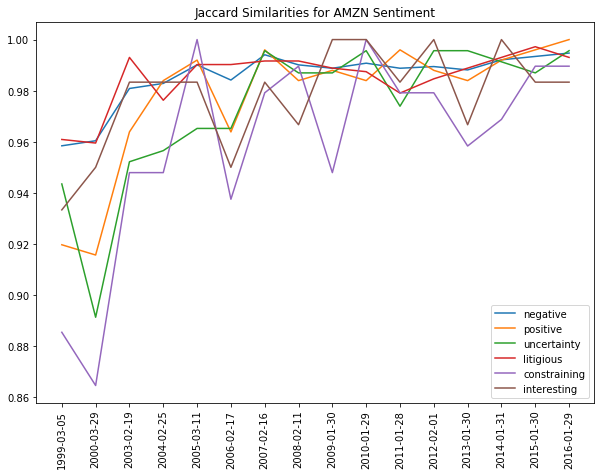

```python
# Get dates for the universe
file_dates = {
    ticker: [ten_k['file_date'] for ten_k in ten_ks]
    for ticker, ten_ks in ten_ks_by_ticker.items()}

jaccard_similarities = {
    ticker: {
        sentiment_name: get_jaccard_similarity(sentiment_values)
        for sentiment_name, sentiment_values in ten_k_sentiments.items()}
    for ticker, ten_k_sentiments in sentiment_bow_ten_ks.items()}


project_helper.plot_similarities(
    [jaccard_similarities[example_ticker][sentiment] for sentiment in sentiments],
    file_dates[example_ticker][1:],
    'Jaccard Similarities for {} Sentiment'.format(example_ticker),
    sentiments)
```

### TFIDF

using the sentiment word lists, let's generate sentiment TFIDF from the 10-k documents. Implement `get_tfidf` to generate TFIDF from each document, using sentiment words as the terms. You can ignore words that are not in `sentiment_words`.

```python
from sklearn.feature_extraction.text import TfidfVectorizer


def get_tfidf(sentiment_words, docs):
    """
    Generate TFIDF values from documents for a certain sentiment

    Parameters
    ----------
    sentiment_words: Pandas Series
        Words that signify a certain sentiment
    docs : list of str
        List of documents used to generate bag of words

    Returns
    -------
    tfidf : 2-d Numpy Ndarray of float
        TFIDF sentiment for each document
        The first dimension is the document.
        The second dimension is the word.
    """

    vectorizer = TfidfVectorizer(vocabulary=sentiment_words.values)
    X = vectorizer.fit_transform(docs)
    return X.toarray()


project_tests.test_get_tfidf(get_tfidf)
```

```
Tests Passed
```

Using the `get_tfidf` function, let's generate the TFIDF values for all the documents.

```python
sentiment_tfidf_ten_ks = {}

for ticker, ten_ks in ten_ks_by_ticker.items():
    lemma_docs = [' '.join(ten_k['file_lemma']) for ten_k in ten_ks]

    sentiment_tfidf_ten_ks[ticker] = {
        sentiment: get_tfidf(sentiment_df[sentiment_df[sentiment]]['word'], lemma_docs)
        for sentiment in sentiments}


project_helper.print_ten_k_data([sentiment_tfidf_ten_ks[example_ticker]], sentiments)
```

```
[
  {
    negative: '[[ 0.          0.          0.         ...,  0.   ...
    positive: '[[ 0.22288432  0.          0.         ...,  0.   ...
    uncertainty: '[[ 0.          0.          0.         ...,  0.005...
    litigious: '[[ 0.  0.  0. ...,  0.  0.  0.]\n [ 0.  0.  0. .....
    constraining: '[[ 0.          0.          0.         ...,  0.   ...
    interesting: '[[ 0.01673784  0.          0.         ...,  0.   ...},
]
```

### Cosine Similarity

Using the TFIDF values, we'll calculate the cosine similarity and plot it over time. Implement `get_cosine_similarity` to return the cosine similarities between each tick in time. Since the input, `tfidf_matrix`, is a TFIDF vector for each time period in order, you just need to computer the cosine similarities for each neighboring vector.

```python
from sklearn.metrics.pairwise import cosine_similarity


def get_cosine_similarity(tfidf_matrix):
    """
    Get cosine similarities for each neighboring TFIDF vector/document

    Parameters
    ----------
    tfidf : 2-d Numpy Ndarray of float
        TFIDF sentiment for each document
        The first dimension is the document.
        The second dimension is the word.

    Returns
    -------
    cosine_similarities : list of float
        Cosine similarities for neighboring documents
    """

    score = [np.asscalar(cosine_similarity(c.reshape(1, -1), n.reshape(1, -1))) for c, n in zip(tfidf_matrix, tfidf_matrix[1:])]
    return score


project_tests.test_get_cosine_similarity(get_cosine_similarity)
```

```
Tests Passed
```

Let's plot the cosine similarities over time.

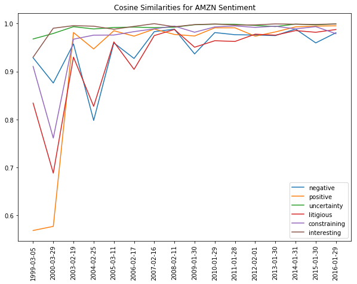

```python
cosine_similarities = {
    ticker: {
        sentiment_name: get_cosine_similarity(sentiment_values)
        for sentiment_name, sentiment_values in ten_k_sentiments.items()}
    for ticker, ten_k_sentiments in sentiment_tfidf_ten_ks.items()}


project_helper.plot_similarities(
    [cosine_similarities[example_ticker][sentiment] for sentiment in sentiments],
    file_dates[example_ticker][1:],
    'Cosine Similarities for {} Sentiment'.format(example_ticker),
    sentiments)
```

## Evaluate Alpha Factors

Just like we did in project 4, let's evaluate the alpha factors. For this section, we'll just be looking at the cosine similarities, but it can be applied to the jaccard similarities as well.

### Price Data

Let's get yearly pricing to run the factor against, since 10-Ks are produced annually.

```python
pricing = pd.read_csv('../../data/project_5_yr/yr-quotemedia.csv', parse_dates=['date'])
pricing = pricing.pivot(index='date', columns='ticker', values='adj_close')


pricing
```

| ticker date | A | AA | AAAP | AABA | AAC | AADR | AAIT | AAL | AAMC | AAME | ... | ZUMZ | ZUO | ZVZZC | ZVZZCNX | ZX | ZXYZ_A | ZYME | ZYNE | ZZK | ZZZ |
| --- | --- | --- | --- | --- | --- | --- | --- | --- | --- | --- | --- | --- | --- | --- | --- | --- | --- | --- | --- | --- | --- |
| 1962-01-01 | nan | nan | nan | nan | nan | nan | nan | nan | nan | nan | ... | nan | nan | nan | nan | nan | nan | nan | nan | nan | nan |
| 1963-01-01 | nan | nan | nan | nan | nan | nan | nan | nan | nan | nan | ... | nan | nan | nan | nan | nan | nan | nan | nan | nan | nan |
| 1964-01-01 | nan | nan | nan | nan | nan | nan | nan | nan | nan | nan | ... | nan | nan | nan | nan | nan | nan | nan | nan | nan | nan |
| 1965-01-01 | nan | nan | nan | nan | nan | nan | nan | nan | nan | nan | ... | nan | nan | nan | nan | nan | nan | nan | nan | nan | nan |
| 1966-01-01 | nan | nan | nan | nan | nan | nan | nan | nan | nan | nan | ... | nan | nan | nan | nan | nan | nan | nan | nan | nan | nan |
| 1967-01-01 | nan | nan | nan | nan | nan | nan | nan | nan | nan | nan | ... | nan | nan | nan | nan | nan | nan | nan | nan | nan | nan |
| 1968-01-01 | nan | nan | nan | nan | nan | nan | nan | nan | nan | nan | ... | nan | nan | nan | nan | nan | nan | nan | nan | nan | nan |
| 1969-01-01 | nan | nan | nan | nan | nan | nan | nan | nan | nan | nan | ... | nan | nan | nan | nan | nan | nan | nan | nan | nan | nan |
| 1970-01-01 | nan | nan | nan | nan | nan | nan | nan | nan | nan | nan | ... | nan | nan | nan | nan | nan | nan | nan | nan | nan | nan |
| 1971-01-01 | nan | nan | nan | nan | nan | nan | nan | nan | nan | nan | ... | nan | nan | nan | nan | nan | nan | nan | nan | nan | nan |
| 1972-01-01 | nan | nan | nan | nan | nan | nan | nan | nan | nan | nan | ... | nan | nan | nan | nan | nan | nan | nan | nan | nan | nan |
| 1973-01-01 | nan | nan | nan | nan | nan | nan | nan | nan | nan | nan | ... | nan | nan | nan | nan | nan | nan | nan | nan | nan | nan |
| 1974-01-01 | nan | nan | nan | nan | nan | nan | nan | nan | nan | nan | ... | nan | nan | nan | nan | nan | nan | nan | nan | nan | nan |
| 1975-01-01 | nan | nan | nan | nan | nan | nan | nan | nan | nan | nan | ... | nan | nan | nan | nan | nan | nan | nan | nan | nan | nan |
| 1976-01-01 | nan | nan | nan | nan | nan | nan | nan | nan | nan | nan | ... | nan | nan | nan | nan | nan | nan | nan | nan | nan | nan |
| 1977-01-01 | nan | nan | nan | nan | nan | nan | nan | nan | nan | nan | ... | nan | nan | nan | nan | nan | nan | nan | nan | nan | nan |
| 1978-01-01 | nan | nan | nan | nan | nan | nan | nan | nan | nan | nan | ... | nan | nan | nan | nan | nan | nan | nan | nan | nan | nan |
| 1979-01-01 | nan | nan | nan | nan | nan | nan | nan | nan | nan | nan | ... | nan | nan | nan | nan | nan | nan | nan | nan | nan | nan |
| 1980-01-01 | nan | nan | nan | nan | nan | nan | nan | nan | nan | nan | ... | nan | nan | nan | nan | nan | nan | nan | nan | nan | nan |
| 1981-01-01 | nan | nan | nan | nan | nan | nan | nan | nan | nan | nan | ... | nan | nan | nan | nan | nan | nan | nan | nan | nan | nan |
| 1982-01-01 | nan | nan | nan | nan | nan | nan | nan | nan | nan | nan | ... | nan | nan | nan | nan | nan | nan | nan | nan | nan | nan |
| 1983-01-01 | nan | nan | nan | nan | nan | nan | nan | nan | nan | nan | ... | nan | nan | nan | nan | nan | nan | nan | nan | nan | nan |
| 1984-01-01 | nan | nan | nan | nan | nan | nan | nan | nan | nan | 6.40835399 | ... | nan | nan | nan | nan | nan | nan | nan | nan | nan | nan |
| 1985-01-01 | nan | nan | nan | nan | nan | nan | nan | nan | nan | 10.61223421 | ... | nan | nan | nan | nan | nan | nan | nan | nan | nan | nan |
| 1986-01-01 | nan | nan | nan | nan | nan | nan | nan | nan | nan | 9.04493392 | ... | nan | nan | nan | nan | nan | nan | nan | nan | nan | nan |
| 1987-01-01 | nan | nan | nan | nan | nan | nan | nan | nan | nan | 3.80659044 | ... | nan | nan | nan | nan | nan | nan | nan | nan | nan | nan |
| 1988-01-01 | nan | nan | nan | nan | nan | nan | nan | nan | nan | 3.14982608 | ... | nan | nan | nan | nan | nan | nan | nan | nan | nan | nan |
| 1989-01-01 | nan | nan | nan | nan | nan | nan | nan | nan | nan | 2.32975302 | ... | nan | nan | nan | nan | nan | nan | nan | nan | nan | nan |
| 1990-01-01 | nan | nan | nan | nan | nan | nan | nan | nan | nan | 1.39785181 | ... | nan | nan | nan | nan | nan | nan | nan | nan | nan | nan |
| 1991-01-01 | nan | nan | nan | nan | nan | nan | nan | nan | nan | 0.69892591 | ... | nan | nan | nan | nan | nan | nan | nan | nan | nan | nan |
| 1992-01-01 | nan | nan | nan | nan | nan | nan | nan | nan | nan | 1.51433946 | ... | nan | nan | nan | nan | nan | nan | nan | nan | nan | nan |
| 1993-01-01 | nan | nan | nan | nan | nan | nan | nan | nan | nan | 1.63082711 | ... | nan | nan | nan | nan | nan | nan | nan | nan | nan | nan |
| 1994-01-01 | nan | nan | nan | nan | nan | nan | nan | nan | nan | 2.09677772 | ... | nan | nan | nan | nan | nan | nan | nan | nan | nan | nan |
| 1995-01-01 | nan | nan | nan | nan | nan | nan | nan | nan | nan | 2.15548749 | ... | nan | nan | nan | nan | nan | nan | nan | nan | nan | nan |
| 1996-01-01 | nan | nan | nan | 0.70833333 | nan | nan | nan | nan | nan | 2.85161770 | ... | nan | nan | nan | nan | nan | nan | nan | nan | nan | nan |
| 1997-01-01 | nan | nan | nan | 4.32812500 | nan | nan | nan | nan | nan | 4.71821581 | ... | nan | nan | nan | nan | nan | nan | nan | nan | nan | nan |
| 1998-01-01 | nan | nan | nan | 29.61250000 | nan | nan | nan | nan | nan | 4.54301839 | ... | nan | nan | nan | nan | nan | nan | nan | nan | nan | nan |
| 1999-01-01 | 52.37855258 | nan | nan | 108.17500000 | nan | nan | nan | nan | nan | 2.15548749 | ... | nan | nan | nan | nan | nan | nan | nan | nan | nan | nan |
| 2000-01-01 | 37.09385272 | nan | nan | 15.03000000 | nan | nan | nan | nan | nan | 1.86380242 | ... | nan | nan | nan | nan | nan | nan | nan | nan | nan | nan |
| 2001-01-01 | 19.31590395 | nan | nan | 8.87000000 | nan | nan | nan | nan | nan | 2.05391026 | ... | nan | nan | nan | nan | nan | nan | nan | nan | nan | nan |
| 2002-01-01 | 12.16813872 | nan | nan | 8.17500000 | nan | nan | nan | nan | nan | 1.51899897 | ... | nan | nan | nan | nan | nan | nan | nan | nan | nan | nan |
| 2003-01-01 | 19.81048865 | nan | nan | 22.51500000 | nan | nan | nan | nan | nan | 2.79570362 | ... | nan | nan | nan | nan | nan | nan | nan | nan | nan | nan |
| 2004-01-01 | 16.32807033 | nan | nan | 37.68000000 | nan | nan | nan | nan | nan | 2.88889374 | ... | nan | nan | nan | nan | nan | nan | nan | nan | nan | nan |
| 2005-01-01 | 22.55441748 | nan | nan | 39.18000000 | nan | nan | nan | 35.76072005 | nan | 2.51613326 | ... | 21.61000000 | nan | nan | nan | nan | nan | nan | nan | nan | nan |
| 2006-01-01 | 23.61133822 | nan | nan | 25.54000000 | nan | nan | nan | 51.85015549 | nan | 2.75842757 | ... | 29.54000000 | nan | nan | nan | nan | nan | nan | nan | nan | nan |
| 2007-01-01 | 24.89183834 | nan | nan | 23.26000000 | nan | nan | nan | 14.16371007 | nan | 1.30466169 | ... | 24.36000000 | nan | nan | nan | nan | nan | nan | nan | nan | nan |
| 2008-01-01 | 10.58953275 | nan | nan | 12.20000000 | nan | nan | nan | 7.44292854 | nan | 0.69147070 | ... | 7.45000000 | nan | nan | nan | nan | nan | nan | nan | nan | nan |
| 2009-01-01 | 21.05033797 | nan | nan | 16.78000000 | nan | nan | nan | 4.66025539 | nan | 1.19283355 | ... | 12.72000000 | nan | nan | nan | nan | nan | nan | nan | nan | nan |
| 2010-01-01 | 28.06937567 | nan | nan | 16.63000000 | nan | 28.82785959 | nan | 9.63825546 | nan | 1.89175945 | ... | 26.87000000 | nan | nan | nan | nan | nan | nan | nan | nan | nan |
| 2011-01-01 | 23.66553928 | nan | nan | 16.13000000 | nan | 27.36247977 | nan | 4.88171380 | nan | 1.85276561 | ... | 27.76000000 | nan | nan | nan | 2.99225131 | nan | nan | nan | nan | nan |
| 2012-01-01 | 28.01179940 | nan | nan | 19.90000000 | nan | 30.02536396 | 27.10695167 | 12.99864622 | 82.00000000 | 2.97706591 | ... | 19.41000000 | nan | nan | nan | 2.99000000 | nan | nan | nan | nan | nan |
| 2013-01-01 | 39.53485221 | nan | nan | 40.44000000 | nan | 36.74348283 | 31.27057728 | 24.31228275 | 930.00000000 | 3.96461868 | ... | 26.00000000 | nan | nan | nan | 2.60000000 | nan | nan | nan | nan | nan |
| 2014-01-01 | 39.43238724 | nan | nan | 50.51000000 | 30.92000000 | 36.88899069 | 32.90504993 | 51.89970750 | 310.12000000 | 3.94778326 | ... | 38.63000000 | nan | nan | nan | 1.43000000 | nan | nan | nan | 100.00000000 | 0.50000000 |
| 2015-01-01 | 40.79862571 | nan | 31.27000000 | 33.26000000 | 19.06000000 | 38.06921608 | 30.53000000 | 41.33893271 | 17.16000000 | 4.91270038 | ... | 15.12000000 | nan | nan | nan | 0.79000000 | 14.10000000 | nan | 10.07000000 | 100.00000000 | 1.00000000 |
| 2016-01-01 | 44.93909238 | 28.08000000 | 26.76000000 | 38.67000000 | 7.24000000 | 39.81959334 | nan | 46.08991196 | 53.50000000 | 4.05320152 | ... | 21.85000000 | nan | 100.01000000 | 14.26000000 | 1.19890000 | 8.00000000 | nan | 15.59000000 | 100.00000000 | 25.00000000 |
| 2017-01-01 | 66.65391782 | 53.87000000 | 81.62000000 | 69.85000000 | 9.00000000 | 58.83570736 | nan | 51.80358470 | 81.60000000 | 3.37888199 | ... | 20.82500000 | nan | 100.10000000 | nan | 1.21650000 | nan | 7.59310000 | 12.52000000 | 25.00000000 | 0.01000000 |
| 2018-01-01 | 61.80000000 | 46.88000000 | 81.63000000 | 73.35000000 | 9.81000000 | 52.88000000 | nan | 37.99000000 | 67.90000000 | 2.57500000 | ... | 24.30000000 | 26.74000000 | nan | nan | 1.38000000 | nan | 15.34000000 | 9.17000000 | nan | nan |

57 rows × 11941 columns

### Dict to DataFrame

The alphalens library uses dataframes, so we we'll need to turn our dictionary into a dataframe.

```python
cosine_similarities_df_dict = {'date': [], 'ticker': [], 'sentiment': [], 'value': []}


for ticker, ten_k_sentiments in cosine_similarities.items():
    for sentiment_name, sentiment_values in ten_k_sentiments.items():
        for sentiment_values, sentiment_value in enumerate(sentiment_values):
            cosine_similarities_df_dict['ticker'].append(ticker)
            cosine_similarities_df_dict['sentiment'].append(sentiment_name)
            cosine_similarities_df_dict['value'].append(sentiment_value)
            cosine_similarities_df_dict['date'].append(file_dates[ticker][1:][sentiment_values])

cosine_similarities_df = pd.DataFrame(cosine_similarities_df_dict)
cosine_similarities_df['date'] = pd.DatetimeIndex(cosine_similarities_df['date']).year
cosine_similarities_df['date'] = pd.to_datetime(cosine_similarities_df['date'], format='%Y')


cosine_similarities_df.head()
```

|  | date | sentiment | ticker | value |
| --- | --- | --- | --- | --- |
| 0 | 2016-01-01 | negative | AMZN | 0.98065125 |
| 1 | 2015-01-01 | negative | AMZN | 0.95951741 |
| 2 | 2014-01-01 | negative | AMZN | 0.98838551 |
| 3 | 2013-01-01 | negative | AMZN | 0.97472377 |
| 4 | 2012-01-01 | negative | AMZN | 0.97585100 |

### Alphalens Format

In order to use a lot of the alphalens functions, we need to aligned the indices and convert the time to unix timestamp. In this next cell, we'll do just that.

```python
import alphalens as al


factor_data = {}
skipped_sentiments = []

for sentiment in sentiments:
    cs_df = cosine_similarities_df[(cosine_similarities_df['sentiment'] == sentiment)]
    cs_df = cs_df.pivot(index='date', columns='ticker', values='value')

    try:
        data = al.utils.get_clean_factor_and_forward_returns(cs_df.stack(), pricing, quantiles=5, bins=None, periods=[1])
        factor_data[sentiment] = data
    except:
        skipped_sentiments.append(sentiment)

if skipped_sentiments:
    print('\nSkipped the following sentiments:\n{}'.format('\n'.join(skipped_sentiments)))
factor_data[sentiments[0]].head()
```

```
Dropped 0.0% entries from factor data: 0.0% in forward returns computation and 0.0% in binning phase (set max_loss=0 to see potentially suppressed Exceptions).
max_loss is 35.0%, not exceeded: OK!
Dropped 0.0% entries from factor data: 0.0% in forward returns computation and 0.0% in binning phase (set max_loss=0 to see potentially suppressed Exceptions).
max_loss is 35.0%, not exceeded: OK!
Dropped 0.0% entries from factor data: 0.0% in forward returns computation and 0.0% in binning phase (set max_loss=0 to see potentially suppressed Exceptions).
max_loss is 35.0%, not exceeded: OK!
Dropped 0.0% entries from factor data: 0.0% in forward returns computation and 0.0% in binning phase (set max_loss=0 to see potentially suppressed Exceptions).
max_loss is 35.0%, not exceeded: OK!
Dropped 0.0% entries from factor data: 0.0% in forward returns computation and 0.0% in binning phase (set max_loss=0 to see potentially suppressed Exceptions).
max_loss is 35.0%, not exceeded: OK!
Dropped 0.0% entries from factor data: 0.0% in forward returns computation and 0.0% in binning phase (set max_loss=0 to see potentially suppressed Exceptions).
max_loss is 35.0%, not exceeded: OK!
```

| date | asset | 1D | factor | factor_quantile |
| --- | --- | --- | --- | --- |
| 1994-01-01 | BMY | 0.53264104 | 0.44784189 | 1 |
|  | CVX | 0.22211880 | 0.91363233 | 5 |
|  | FRT | 0.17159556 | 0.47730392 | 3 |
| 1995-01-01 | BMY | 0.32152919 | 0.89403523 | 1 |
|  | CVX | 0.28478156 | 0.91066582 | 3 |

### Alphalens Format with Unix Time

Alphalen's `factor_rank_autocorrelation` and `mean_return_by_quantile` functions require unix timestamps to work, so we'll also create factor dataframes with unix time.

```python
unixt_factor_data = {
    factor: data.set_index(pd.MultiIndex.from_tuples(
        [(x.timestamp(), y) for x, y in data.index.values],
        names=['date', 'asset']))
    for factor, data in factor_data.items()}
```

### Factor Returns

Let's view the factor returns over time. We should be seeing it generally move up and to the right.

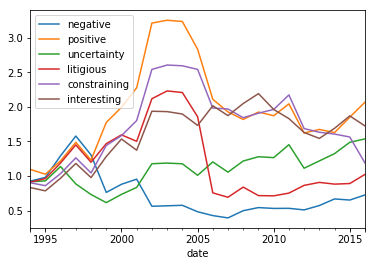

```python
ls_factor_returns = pd.DataFrame()

for factor_name, data in factor_data.items():
    ls_factor_returns[factor_name] = al.performance.factor_returns(data).iloc[:, 0]

(1 + ls_factor_returns).cumprod().plot()
```

### Basis Points Per Day per Quantile

It is not enough to look just at the factor weighted return. A good alpha is also monotonic in quantiles. Let's looks the basis points for the factor returns.

[output not shown]

[figure not shown]

```python
qr_factor_returns = pd.DataFrame()

for factor_name, data in unixt_factor_data.items():
    qr_factor_returns[factor_name] = al.performance.mean_return_by_quantile(data)[0].iloc[:, 0]

(10000*qr_factor_returns).plot.bar(
    subplots=True,
    sharey=True,
    layout=(5,3),
    figsize=(14, 14),
    legend=False)
```

### Turnover Analysis

Without doing a full and formal backtest, we can analyze how stable the alphas are over time. Stability in this sense means that from period to period, the alpha ranks do not change much. Since trading is costly, we always prefer, all other things being equal, that the ranks do not change significantly per period. We can measure this with the **Factor Rank Autocorrelation (FRA)**.

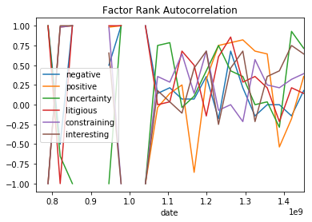

```python
ls_FRA = pd.DataFrame()

for factor, data in unixt_factor_data.items():
    ls_FRA[factor] = al.performance.factor_rank_autocorrelation(data)

ls_FRA.plot(title="Factor Rank Autocorrelation")
```

### Sharpe Ratio of the Alphas

The last analysis we'll do on the factors will be sharpe ratio. Let's see what the sharpe ratio for the factors are. Generally, a Sharpe Ratio of near 1.0 or higher is an acceptable single alpha for this universe.

```python
daily_annualization_factor = np.sqrt(252)

(daily_annualization_factor * ls_factor_returns.mean() / ls_factor_returns.std()).round(2)
```

```
negative       0.39000000
positive       4.17000000
uncertainty    3.05000000
litigious      1.97000000
constraining   1.92000000
interesting    3.49000000
dtype: float64
```

That's it! You've successfully done sentiment analysis on 10-ks!

## Submission

Now that you're done with the project, it's time to submit it. Click the submit button in the bottom right. One of our reviewers will give you feedback on your project with a pass or not passed grade. You can continue to the next section while you wait for feedback.